# Analysis of Institute on Race and Political Economy Guaranteed Income Proposal

Jack Landry

5/24/2021

## Explination of Program

1. *Single filers:* Benefit of $12,500, phase out starts at $10,000, ends at $50,000
2. *Married/Cohabitating filers:* Benefit of $25,000, phase out starts at $15,000, ends at $70,000
3. *Child benefit:* $4,500/child, no cap, same phase out structure as the main benefit.

[figure not shown]

The Hamilton proposal differs from the standard EITC in several ways. The most important change in the lack of phase in–Hamilton gives people with no taxable earnings the full benefit, while the standard EITC would give people nothing. Hamilton’s program is also more generous, almost everyone will receive a larger benefit than the existing EITC. However, the benefits have a much more aggressive phase out relative to the standard EITC. The phase out are especially large families with more children–these families see a larger benefit but see the same phase in and phase out thresholds as people with no children, which necessitates a much steeper slope.

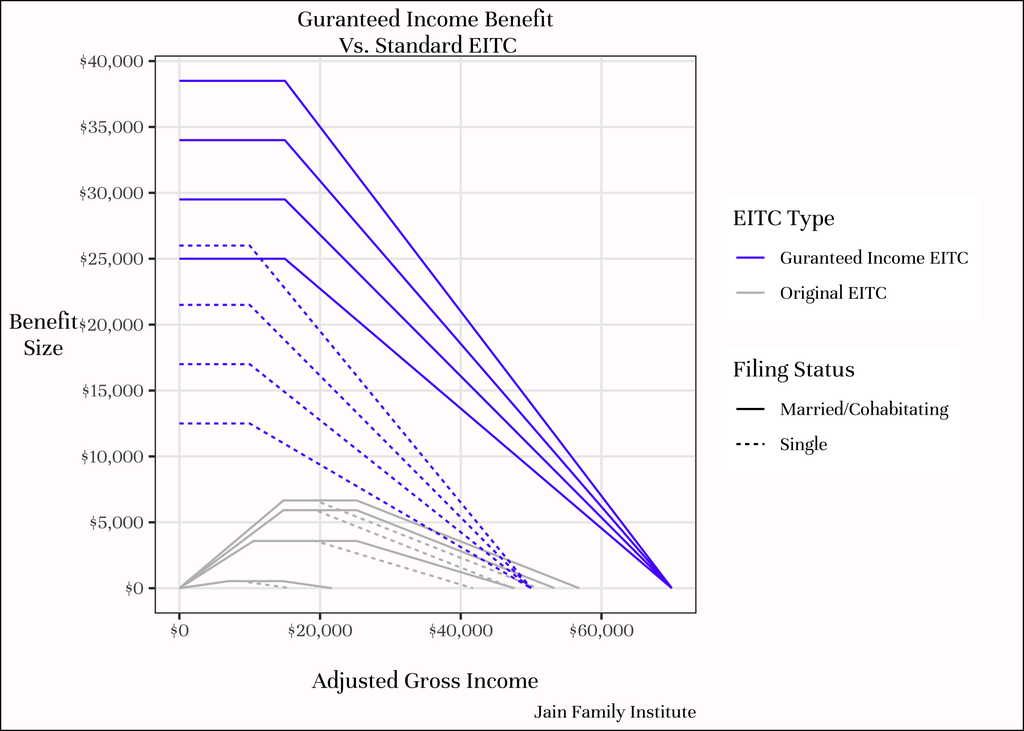

## Explaining Hamilton Analysis Errors

I estimate that if everyone eligible for the program received the full benefit they were entitled to, the program would cost $1.4 trillion dollars.[^1] Hamilton estimates the program cost at $876 billion dollars. This discrepancy is caused by several different facets of modeling assumptions, which I detail in the following sections.

Although I estimate the Hamilton program is significantly more expensive than advertised, that does not necessarily mean that they underestimate the cost of eliminating poverty. The larger cost I estimate means that more benefits are going out the door. For instance, Hamilton estimates that the program will boost median family income by $5,691, while my estimate is $11,881.[^2] If you change the program rules, it may be possible achieve the same poverty reductions with costs close to what Hamilton estimates.[^3]

### Phase out rates

Hamilton writes that the phase out rate for singles is 31.9% and the phase out rate for couples is 46.4%. These proposed phase out rates are slightly inconsistent with how they describe the program rules. Take singles: with a benefit of $12,500, a phase out that starts at $10,000 and ends at $50,000, the phase out rate should be 31.25%. This comes from the formula for calculating a slope.
$$m
= \frac{\Delta y}{\Delta x}
= \frac{y_2 - y_1}{x_2 - x_1}
= \frac{12,500 - 0}{10,000 - 50,000}
= 31.25\%$$
Similarly, the phase out for couples is
$$m = \frac{\Delta y}{\Delta x}
= \frac{y_2 - y_1}{x_2 - x_1}
= \frac{25,000 - 0}{15,000 - 70,000}
= 45.45\%$$
The general benefit calculation is for people with a income between the phase out start and end points is
$$benefit = max\_benefit - (income - phase\_out\_start) * phase\_out\_rate$$
where the phase out rate comes from the calculation for the slope
$$m
= \frac{\Delta y}{\Delta x}
= \frac{y_2 - y_1}{x_2 - x_1}
= \frac{max\_benefit - 0}{phase\_out\_start - phase\_out\_end}
= phase\_out\_rate$$
The maximum benefit is either $12,500 or $25,000, depending on filing status, with the addition of $4,500 times the number of children in the household.

These errors in calculating the phase out rate lead to small discrepancies in the benefit calculation of hypothetical households with $40,000 of income, shown in Hamilton’s Table 1. Note that the benefit values in the table are also inconsistent with Hamilton’s phase outs, but none of the errors are larger than $500.

**Singles**

| Refund Recepient | Refund Amount Hamilton | Corrected Refund Amount | Difference |
| --- | --- | --- | --- |
| Adult | $3,269 | $3,125 | $144 |
| Child 1 | $1,159 | $1,125 | $34 |
| Child 2 | $2,318 | $2,250 | $68 |

**Couples**

| Refund Recepient | Refund Amount Hamilton | Corrected Refund Amount | Difference |
| --- | --- | --- | --- |
| Couple | $14,048 | $13,636 | $412 |
| Child 1 | $ 2,475 | $ 2,455 | $20 |
| Child 2 | $ 4,958 | $ 4,909 | $49 |

### Household Construction

To model benefits and estimate cost, Hamilton uses the Survey of Consumer Finances (SCF) summary extract data. This is a commonly used, high-quality survey with detailed information on income and wealth. However, the summary extract have data on households, not individuals. For tax filing purposes (and how the Hamilton program is described), the only income data relevant is your personal income or your combined income with a cohabitating partner. When there are multiple adult individuals in a household, they will often file taxes separately based on their individual incomes, but Hamilton only has information on household combined income. Since combined incomes are higher than individual incomes by construction, using household income to determine eligibility decreases the number of people who appear eligible and thus the estimated cost of the program. In the appendix, Hamilton describes a correction for households with three or more adults:

> Finally, the SCF data also accounts for households with three or more adults, while the tax system only allows for single and two-adult filings. To estimate the economic effects of our program for households in the SCF data with three or more adults, we adopt a simplifying convention: households with three or more adults receive up to $30,000 total for those households with income up to $30,000, declining at a rate of 50 percent above $30,000 to fully phase out at $80,000 in total household income across all adults. Because this category only represents a small proportion of total households, the choice of how to estimate the grant amounts for these households will not significantly affect the overall program cost. Under an alternative assumption that every non-married adult (with two or more adults in the household) file separately, that divides household income in a way that maximizes the refund value, our guaranteed income program cost still remains under $1 trillion.

### Adjusted Gross Income vs. Total Income

To determine eligibility for the program, the Hamilton plan calls for using adjusted gross income (a.k.a taxable income). However, in their analysis of the SCF, they use a total income measure, which does not adjust for types of income that are not taxable. By construction, this income measure will increase people’s measure income compare to their taxable income an underestimate eligability for the program.

## Analysis of Program

### Average Tax Rate Analysis

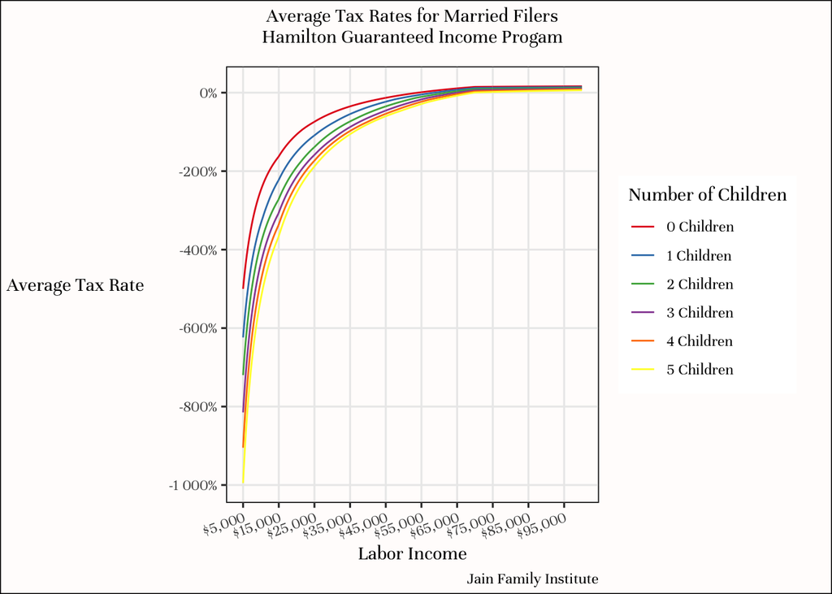

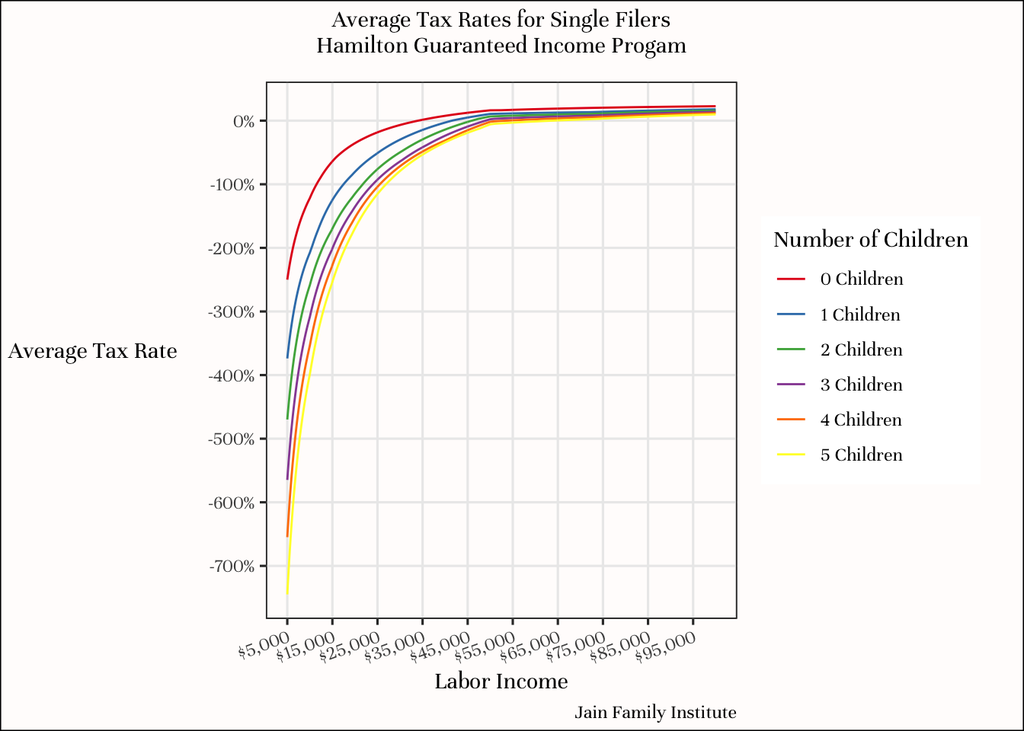

### Marginal Tax Rate Analysis

I should also plot pre tax vs. post tax income.

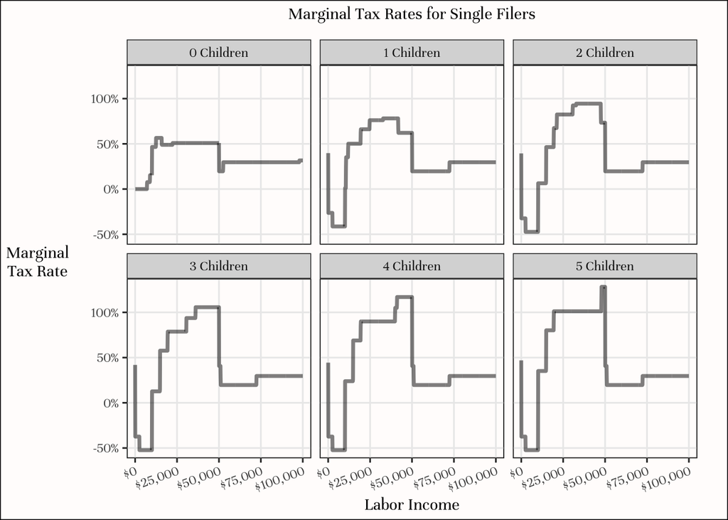

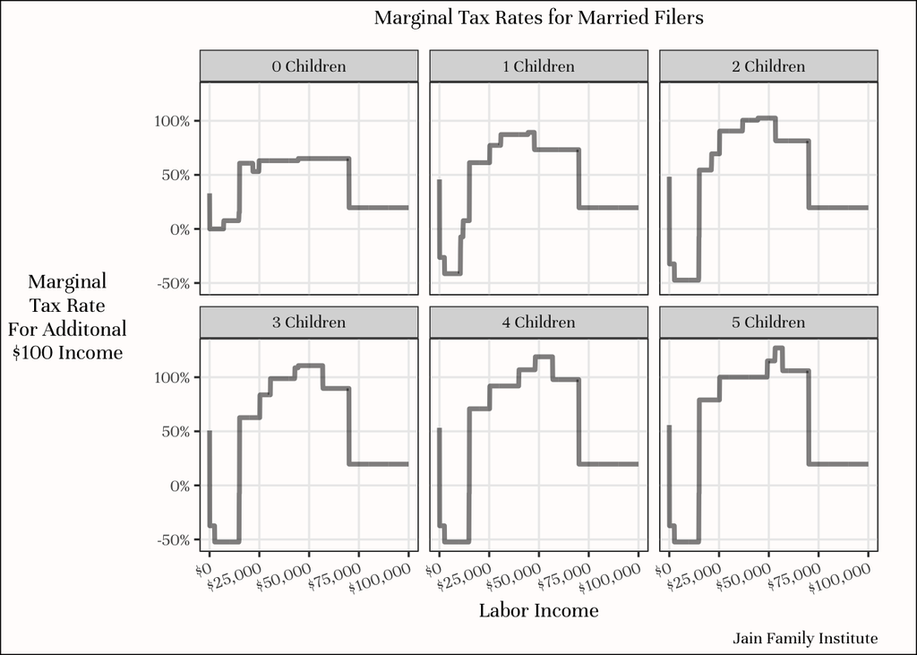

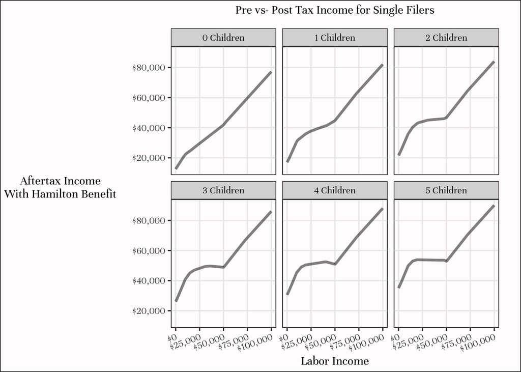

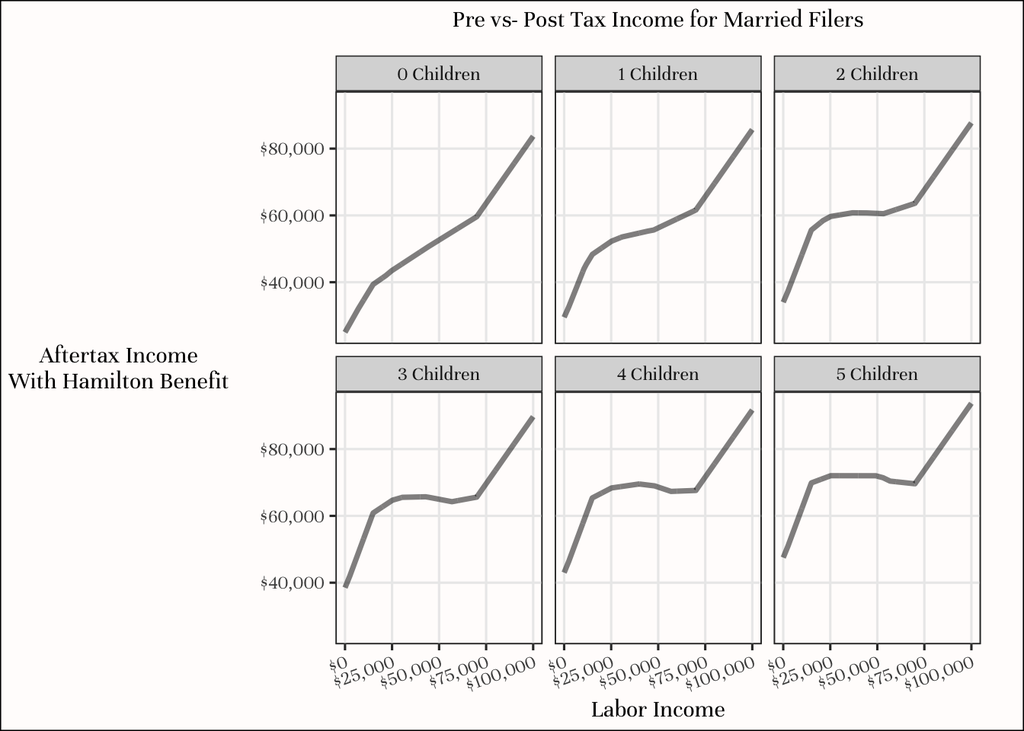

[^1]: This uses data on incomes from 2019, the same year of analysis of the Hamilton program.
[^2]: My estimate is of median family income measure on the individual level, e.g. weighted by family size. Need to check if Hamilton clarifies that.
[^3]: In practice, it might be impossible to achieve the same poverty impacts conditional on size due to difficulties targeting poor families with a tax code that emphasizes individual income.